# Decorrelation-Based SOTA: Activity

Jose Tamez

2024-03-04

# 1 Effect of UPSTM-Based Decorrelation on ML Performance

### 1.0.1 Loading the libraries

```r
library("FRESA.CAD")
library(readxl)
library(igraph)
library(umap)
library(tsne)
library(entropy)

op <- par(no.readonly = TRUE)
pander::panderOptions('digits', 3)
pander::panderOptions('table.split.table', 400)
pander::panderOptions('keep.trailing.zeros',TRUE)
source("C:/Users/jtame/Documents/GitHub/LatentBiomarkers/RMD/DecorrelationCV.R")
```

## 1.1 Material and Methods

Data Source https://www.ncbi.nlm.nih.gov/pmc/articles/PMC6960825/

Mohino-Herranz I, Gil-Pita R, Rosa-Zurera M, Seoane F. Activity Recognition Using Wearable Physiological Measurements: Selection of Features from a Comprehensive Literature Study. Sensors (Basel). 2019 Dec 13;19(24):0. doi: 10.3390/s19245524. PMID: 31847261; PMCID: PMC6960825.

## 1.2 The Data

```r
Activitydata <- read.csv("~/GitHub/LatentBiomarkers/Data/ActivityData/data.txt", header=FALSE, stringsAsFactors=TRUE)
featNames <- read.table("~/GitHub/LatentBiomarkers/Data/ActivityData/Featurelabels.txt", quote="\"", comment.char="")
featNames <- as.character(t(featNames))
featNames <- str_replace_all(featNames,"\\(abs\\)","_A_")
featNames[duplicated(featNames)] <- paste(featNames[duplicated(featNames)],"D",sep="_")

rep_ID <- numeric(nrow(Activitydata))
ctr <- 1
for (ind in c(1:(nrow(Activitydata)-1)))
{
  rep_ID[ind] <- ctr
  if (Activitydata$V1[ind] != Activitydata$V1[ind+1]) ctr <- 0;
  ctr <- ctr + 1
}
rownames(Activitydata) <- paste(Activitydata$V1,rep_ID,sep="_")
colnames(Activitydata) <- c("ID",featNames,"class")
Activitydata$rep <- rep_ID

tb <- table(Activitydata$class)

classes <- c("Neu","Emo","Men","Phy")
names(classes) <- names(tb)
Activitydata$class <- classes[as.character(Activitydata$class)]
table(Activitydata$class)
```

```
#>
#>  Emo  Men  Neu  Phy
#> 1120 1120 1120 1120
```

```r
ID_class <- paste(Activitydata$ID,Activitydata$class)
IDCLASS <- unique(ID_class)
theclass <- Activitydata$class[!duplicated(ID_class)]
theIDs <- Activitydata$ID[!duplicated(ID_class)]

ActivitydataAvg <- NULL
for (id in IDCLASS)
{
  ActivitydataAvg <- rbind(ActivitydataAvg,apply(Activitydata[ID_class==id,featNames],2,mean))
}
colnames(ActivitydataAvg) <- featNames
rownames(ActivitydataAvg) <- IDCLASS
ActivitydataAvg <- as.data.frame(ActivitydataAvg)
ActivitydataAvg$class <- theclass
ActivitydataAvg$ID <- theIDs

table(ActivitydataAvg$class)
```

```
#>
#> Emo Men Neu Phy
#>  40  40  40  40
```

```r
ActivitydataAvg <- subset(ActivitydataAvg, class=="Men" | class=="Emo")

ActivitydataAvg$class <- 1*(ActivitydataAvg$class == "Men")
table(ActivitydataAvg$class)
```

```
#>
#>  0  1
#> 40 40
```

#### 1.2.0.1 Standarize the names for the reporting

```r
studyName <- "Activity"
dataframe <- ActivitydataAvg
outcome <- "class"
nLoops <- 50
tfrac <- 0.80

needScaling <- TRUE
IDSample <- TRUE
thro <- 0.8

mvs <- multivariate_BinEnsemble(dataframe,"class")

#bsm <- BSWiMS.model(class~.,dataframe,loops=1,elimination.bootstrap.steps=0,print=TRUE)
```

## 1.3 CV Analysis and report

### 1.3.1 Libraries

```r
library(xgboost)
library("vioplot")
```

## 1.4 XGB interface

```r
s3xgb <- function(formula=formula,data=NULL,...)
{
  if (inherits(formula, "character"))
    {
        formula <- formula(formula);
    }
    dependent <- all.vars(formula)
    Outcome = dependent[1];

  thexbcol <- colnames(data)[(colnames(data) != Outcome)]
  xbst <- xgboost(data = as.matrix(data[,thexbcol]), label = data[,Outcome],
                max_depth = 30, eta = 0.05, nthread = 12, nrounds = 100,
                objective = "binary:logistic",verbose = 0)
  class(xbst) <- c("S3XBST",class(xbst))
  attr(xbst,"trainnames") <-  thexbcol
  return (xbst)
}
predict.S3XBST <- function(object,...)
{
  parameters <- list(...);
    testData <- parameters[[1]];
    class(object) <- class(object)[2]
  pred <- predict(object,as.matrix(testData[,attr(object,"trainnames")]))
  return(pred)
}
```

## 1.5 SOTA Comparison to XGB, SVM and LASSO

### 1.5.1 XGB

```r
XBOOSTcv <- randomCV(dataframe,outcome,s3xgb,
                        trainFraction = tfrac,
                        repetitions = nLoops,
                        classSamplingType ="Ba")
```

……….10 Tested: 69 Avg. Selected: 0 Min Tests: 1 Max Tests: 6 Mean Tests: 2.318841 . MAD: 0.3974085

……….20 Tested: 80 Avg. Selected: 0 Min Tests: 1 Max Tests: 8 Mean Tests: 4 . MAD: 0.3865532

……….30 Tested: 80 Avg. Selected: 0 Min Tests: 2 Max Tests: 12 Mean Tests: 6 . MAD: 0.3856457

……….40 Tested: 80 Avg. Selected: 0 Min Tests: 2 Max Tests: 14 Mean Tests: 8 . MAD: 0.3958238

……….50 Tested: 80 Avg. Selected: 0 Min Tests: 4 Max Tests: 17 Mean Tests: 10 . MAD: 0.394311

```r
XGBbs <- predictionStats_binary(XBOOSTcv$medianTest,"XGB: CV")
```

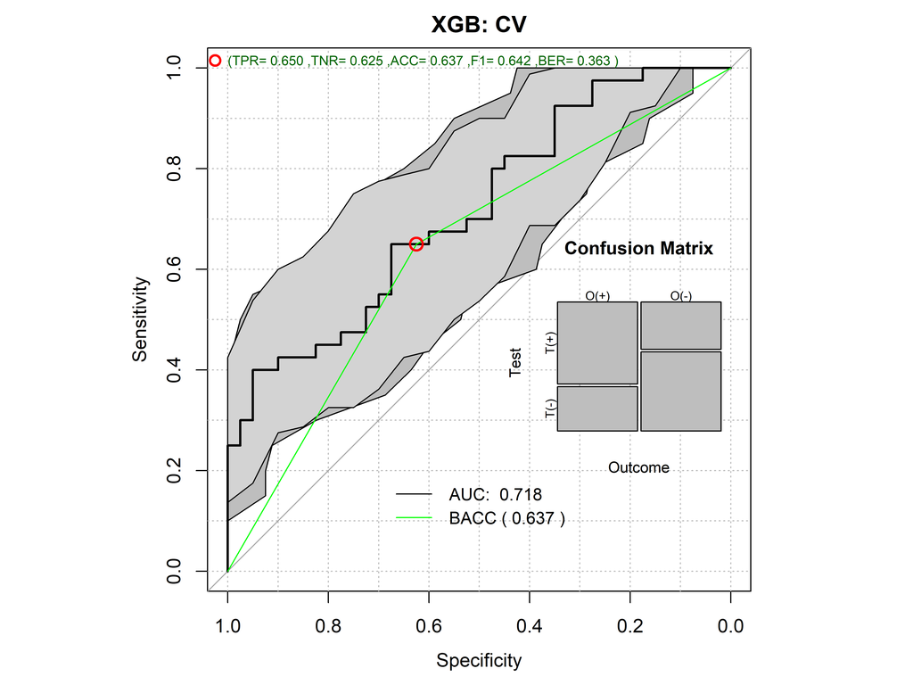

### 1.5.2 ILAA XGB

```r
ILAAXGBcv <- randomCV(fittingFunction = filteredFit,
                     trainSampleSets = XBOOSTcv$trainSamplesSets,
                     fitmethod = s3xgb,
                      filtermethod = NULL,
                    DECOR = TRUE,
                    DECOR.control=list(thr=thro)
                    )
```

……….10 Tested: 69 Avg. Selected: 534 Min Tests: 1 Max Tests: 6 Mean Tests: 2.318841 . MAD: 0.3467133

……….20 Tested: 80 Avg. Selected: 534 Min Tests: 1 Max Tests: 8 Mean Tests: 4 . MAD: 0.296499

……….30 Tested: 80 Avg. Selected: 534 Min Tests: 2 Max Tests: 12 Mean Tests: 6 . MAD: 0.2935326

……….40 Tested: 80 Avg. Selected: 534 Min Tests: 2 Max Tests: 14 Mean Tests: 8 . MAD: 0.2830115

……….50 Tested: 80 Avg. Selected: 534 Min Tests: 4 Max Tests: 17 Mean Tests: 10 . MAD: 0.2847277

```r
ILAAXGBbs <- predictionStats_binary(ILAAXGBcv$medianTest,"ILAA-XGB: CV")
```

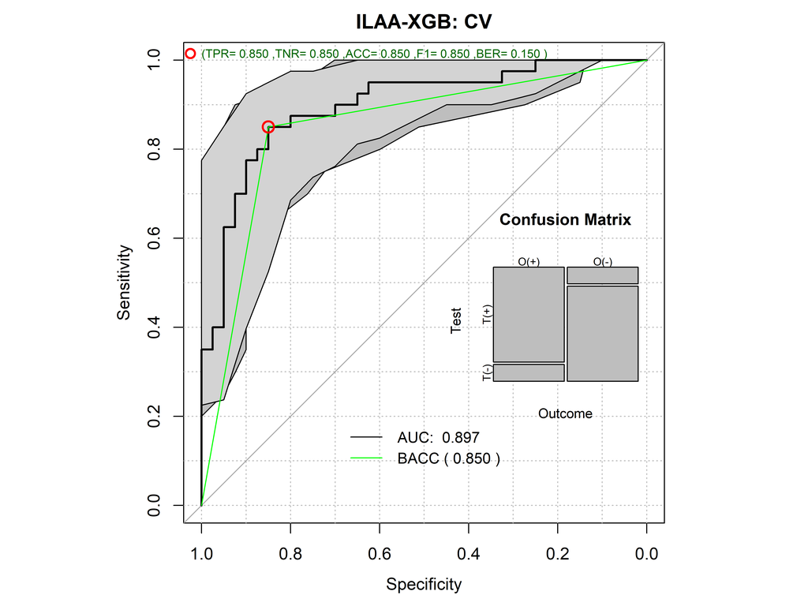

### 1.5.3 LASSO

```r
LASSOcv <- randomCV(fittingFunction = LASSO_MIN,
                     trainSampleSets = XBOOSTcv$trainSamplesSets,
                    family="binomial")
```

……….10 Tested: 69 Avg. Selected: 10.4 Min Tests: 1 Max Tests: 6 Mean Tests: 2.318841 . MAD: 0.4570886

……….20 Tested: 80 Avg. Selected: 9.6 Min Tests: 1 Max Tests: 8 Mean Tests: 4 . MAD: 0.4644123

……….30 Tested: 80 Avg. Selected: 9.2 Min Tests: 2 Max Tests: 12 Mean Tests: 6 . MAD: 0.4671595

……….40 Tested: 80 Avg. Selected: 9.125 Min Tests: 2 Max Tests: 14 Mean Tests: 8 . MAD: 0.4661633

……….50 Tested: 80 Avg. Selected: 7.9 Min Tests: 4 Max Tests: 17 Mean Tests: 10 . MAD: 0.4712215

```r
LASSObs <- predictionStats_binary(LASSOcv$medianTest,"LASSO: CV")
```

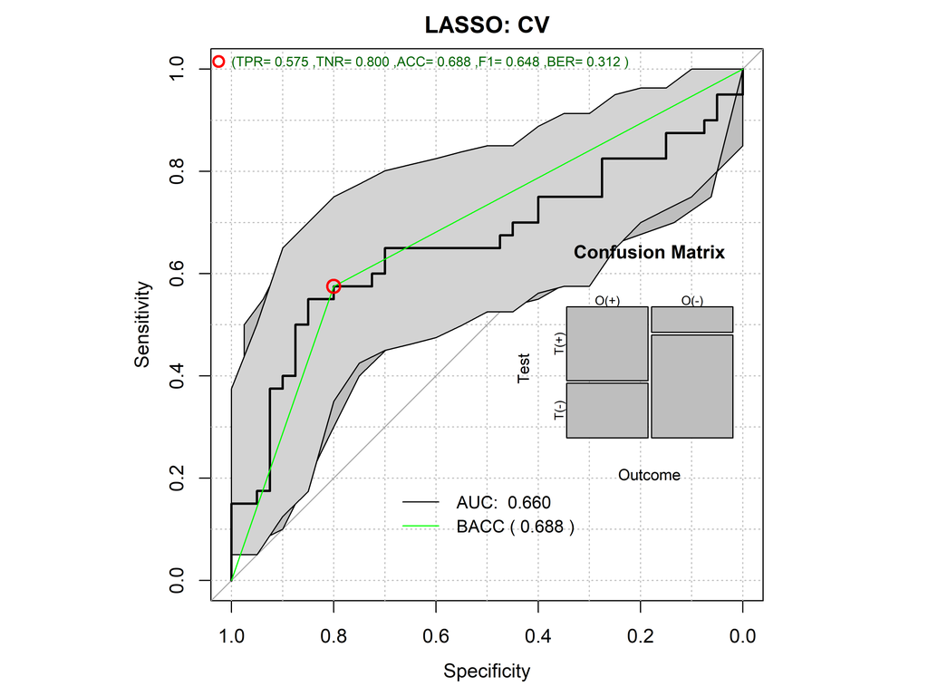

### 1.5.4 ILAA LASSO

```r
ILAALASSOcv <- randomCV(fittingFunction = filteredFit,
                     trainSampleSets = XBOOSTcv$trainSamplesSets,
                     fitmethod = LASSO_MIN,
                      filtermethod = NULL,
                    DECOR = TRUE,
                    DECOR.control=list(thr=thro),
                    family="binomial")
```

……….10 Tested: 69 Avg. Selected: 19.4 Min Tests: 1 Max Tests: 6 Mean Tests: 2.318841 . MAD: 0.3154062

……….20 Tested: 80 Avg. Selected: 20 Min Tests: 1 Max Tests: 8 Mean Tests: 4 . MAD: 0.3092784

……….30 Tested: 80 Avg. Selected: 19.46667 Min Tests: 2 Max Tests: 12 Mean Tests: 6 . MAD: 0.3186973

……….40 Tested: 80 Avg. Selected: 19.95 Min Tests: 2 Max Tests: 14 Mean Tests: 8 . MAD: 0.3118769

……….50 Tested: 80 Avg. Selected: 20.12 Min Tests: 4 Max Tests: 17 Mean Tests: 10 . MAD: 0.310993

```r
ILAALASSObs <- predictionStats_binary(ILAALASSOcv$medianTest,"ILLA-LASSO: CV")
```

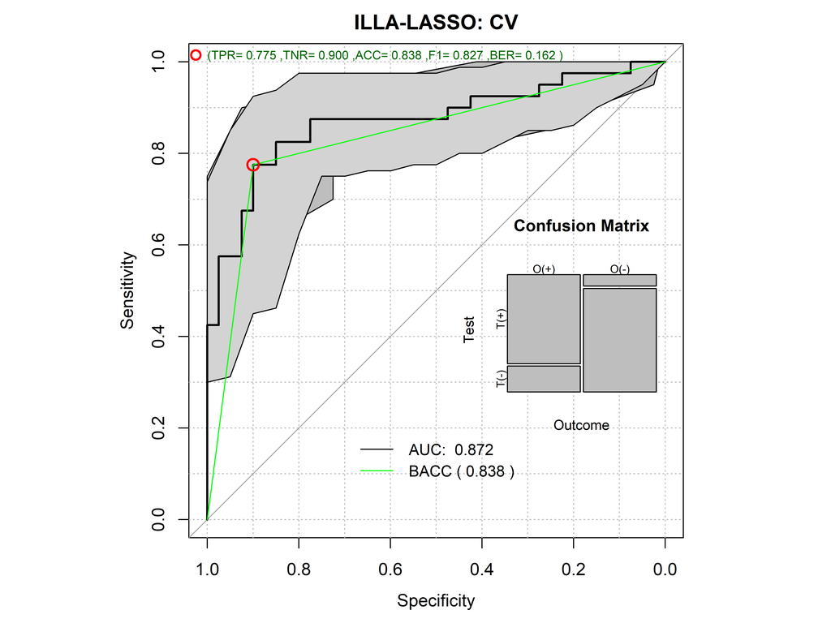

### 1.5.5 SVM

```r
SVMcv <- randomCV(fittingFunction = filteredFit,
                  trainSampleSets = XBOOSTcv$trainSamplesSets,
                  asFactor = TRUE,
                  filtermethod = multivariate_BinEnsemble,
                  filtermethod.control=NULL,
                  probability=TRUE)
```

………..10 Tested: 69 Avg. Selected: 21.2 Min Tests: 1 Max Tests: 6 Mean Tests: 2.318841 . MAD: 0.4252254

………..20 Tested: 80 Avg. Selected: 23.1 Min Tests: 1 Max Tests: 8 Mean Tests: 4 . MAD: 0.4170167

………..30 Tested: 80 Avg. Selected: 23.23333 Min Tests: 2 Max Tests: 12 Mean Tests: 6 . MAD: 0.4179091

……….40 Tested: 80 Avg. Selected: 23.45 Min Tests: 2 Max Tests: 14 Mean Tests: 8 . MAD: 0.42224

……….50 Tested: 80 Avg. Selected: 22.3 Min Tests: 4 Max Tests: 17 Mean Tests: 10 . MAD: 0.4180892

```r
SVMbs <- predictionStats_binary(SVMcv$medianTest,"SVM: CV")
```

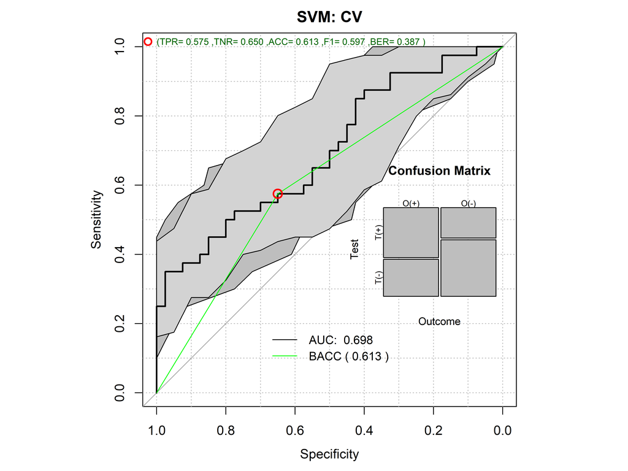

### 1.5.6 ILAAA SVM

```r
ILLASVMcv <- randomCV(dataframe,outcome,fittingFunction = filteredFit,
                  trainSampleSets = XBOOSTcv$trainSamplesSets,
                  asFactor = TRUE,
                  DECOR = TRUE,
                  DECOR.control=list(thr=thro),
                  filtermethod = multivariate_BinEnsemble,
                  filtermethod.control=NULL,
                  probability=TRUE)
```

…………….10 Tested: 69 Avg. Selected: 38.8 Min Tests: 1 Max Tests: 6 Mean Tests: 2.318841 . MAD: 0.3412009

…………..20 Tested: 80 Avg. Selected: 38.15 Min Tests: 1 Max Tests: 8 Mean Tests: 4 . MAD: 0.3412167

……………30 Tested: 80 Avg. Selected: 37.66667 Min Tests: 2 Max Tests: 12 Mean Tests: 6 . MAD: 0.3356324

…………..40 Tested: 80 Avg. Selected: 37.725 Min Tests: 2 Max Tests: 14 Mean Tests: 8 . MAD: 0.3416349

…………50 Tested: 80 Avg. Selected: 37 Min Tests: 4 Max Tests: 17 Mean Tests: 10 . MAD: 0.3346881

```r
ILLASVMbs <- predictionStats_binary(ILLASVMcv$medianTest,"ILLA-SVM: CV")
```

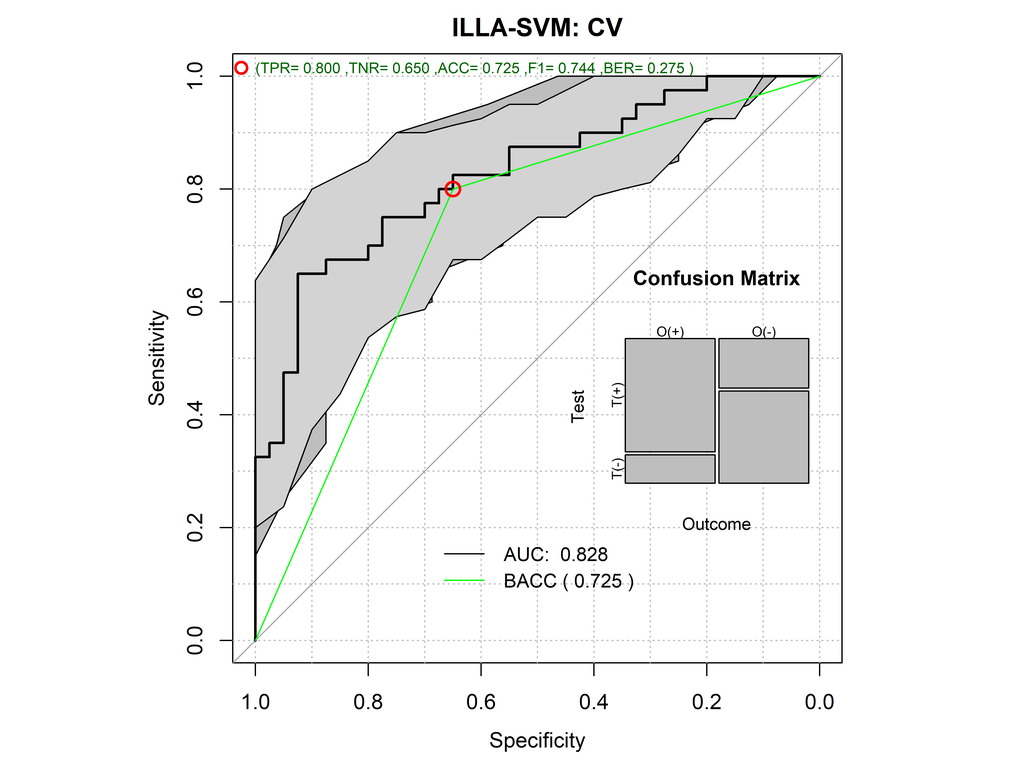

## 1.6 The Reports

```r
par(op)
AUCTABLE <- rbind(
                  XGBbs$aucs,
                  SVMbs$aucs,
                  LASSObs$aucs,
                  ILAAXGBbs$aucs,
                  ILLASVMbs$aucs,
                  ILAALASSObs$aucs
                  )
colnames(AUCTABLE) <- c("Median","Lower","Upper")
rownames(AUCTABLE) <- c("XGB","SVM","LASSO",
                        "ILAA-XGB","ILAA-SVM","ILAA-LASSO")

pander::pander(AUCTABLE)
```

|  | Median | Lower | Upper |
| --- | --- | --- | --- |
| **XGB** | 0.718 | 0.607 | 0.828 |
| **SVM** | 0.698 | 0.584 | 0.813 |
| **LASSO** | 0.660 | 0.535 | 0.785 |
| **ILAA-XGB** | 0.897 | 0.828 | 0.967 |
| **ILAA-SVM** | 0.828 | 0.738 | 0.918 |
| **ILAA-LASSO** | 0.872 | 0.790 | 0.954 |

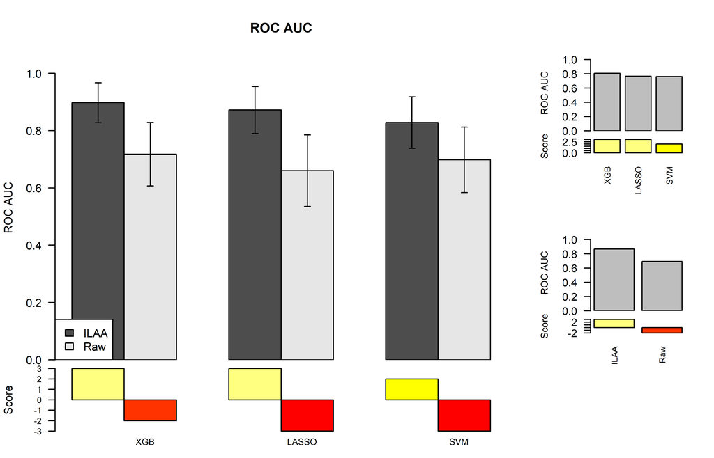

```r
thesets <- c("XGB","SVM","LASSO")
themethod <- c("Raw","ILAA")
pauc <- barPlotCiError(AUCTABLE,
               "ROC AUC",
               thesets=thesets,
               themethod=themethod,
               main="ROC AUC",
               angle=0,
               offsets=c(0.1,1.0),
               scoreDirection=">",args.legend=list(x="bottomleft"))

par(op)
```

```r
BERTABLE <- rbind(
                  XGBbs$berror,
                  SVMbs$berror,
                  LASSObs$berror,
                  ILAAXGBbs$berror,
                  ILLASVMbs$berror,
                  ILAALASSObs$berror
                  )


colnames(BERTABLE) <- colnames(AUCTABLE)
rownames(BERTABLE) <- rownames(AUCTABLE)

pander::pander(BERTABLE)
```

|  | Median | Lower | Upper |
| --- | --- | --- | --- |
| **XGB** | 0.363 | 0.2575 | 0.466 |
| **SVM** | 0.389 | 0.2841 | 0.501 |
| **LASSO** | 0.312 | 0.2169 | 0.419 |
| **ILAA-XGB** | 0.149 | 0.0754 | 0.236 |
| **ILAA-SVM** | 0.275 | 0.1771 | 0.376 |
| **ILAA-LASSO** | 0.161 | 0.0872 | 0.249 |

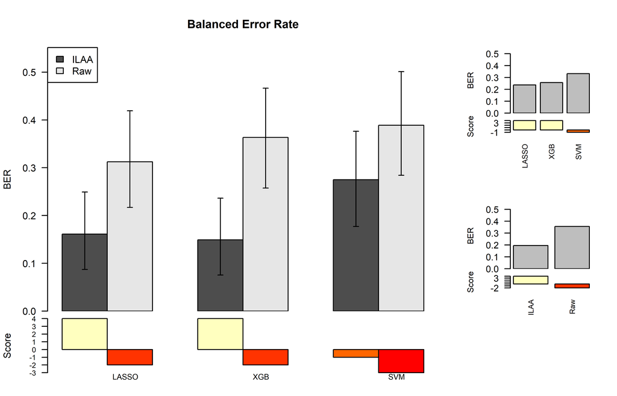

```r
pber <- barPlotCiError(BERTABLE,
               "BER",
               thesets=thesets,
               themethod=themethod,
               main="Balanced Error Rate",
               angle=0,
               offsets=c(0.1,0.5),
               scoreDirection="<",args.legend=list(x="topleft"))
```

### 1.6.1 Saving ALL

```r
save.image(paste("SOTACV_analyiss",studyName,".RData",sep="_"))
```